# When personalization deters delegation to algorithms — Replication analysis

Lara Suraci & Irenaeus Wolff

26 Juni 2026

```r
library(dplyr)
library(tidyr)
library(ggplot2)
library(scales)
library(Exact)     # Boschloo exact test
library(fixest)    # LPM with fixed effects + clustered SE
library(lmtest)    # robust coefficient tests
library(sandwich)  # HC2 standard errors
library(texreg)    # regression tables
```

# Data import and preparation

## Shared plotting constants

To keep figures visually consistent we fix the treatment colour palette once.

```r
# Treatment colours used throughout (Pref = preference-based, EV = optimisation)
col_pref <- "#4E79A7"
col_ev   <- "#D55E00"
algo_cols <- c("Pref" = col_pref, "EV" = col_ev)
```

## Load raw data

Paths are relative to this script’s location (replication-package layout).

```r
choices <- read.delim("260206_1528_537_lotteryChoices.xls")
subjects <- read.csv("allSubjects.csv", header = TRUE)
prolificData <- read.csv("prolific_demographic_export_approved.csv")

choicesP1 <- subset(choices, Part == 1)
```

## Preregistered exclusions

We apply the preregistered exclusion rules: failed bot/slider check at first attempt, failed comprehension checks after the second attempt, failure to confirm careful participation (`Reliable < 6`), disclosed AI usage, incomplete data (`Delegated < 0`), and the log-time “too fast” rule.

```r
# "Too fast" flag based on the preregistered log-completion-time rule
prolificData$logCompleTime <- log(prolificData$Time.taken)
prolificData$tooFast <- 1 * (
  prolificData$logCompleTime <
    mean(log(prolificData$Time.taken)) - 2 * sd(log(prolificData$Time.taken))
)

keep_ids <- prolificData$Participant.id[prolificData$tooFast == 0]

choices <- subset(
  choices,
  BotCheck1attempt == 1 &
    Part1CQsPassedOnAttempt <= 2 &
    Part2CQsPassedOnAttempt <= 2 &
    Reliable >= 6 &
    AIUsageInStudy == 0 &
    Delegated >= 0 &
    ProlificID %in% keep_ids
)

subjects  <- subset(subjects,  ProlificID %in% choices$ProlificID)
choicesP1 <- subset(choicesP1, ProlificID %in% choices$ProlificID)

# Final analysis sample (paper: N = 233; EV = 118, Pref = 115)
cat("Final sample size per condition (1 = EV, 0 = Preference-based):\n")
```

```
## Final sample size per condition (1 = EV, 0 = Preference-based):
```

```r
table(subjects$EVAlgorithm)
```

```
##
##   0   1
## 115 118
```

```r
# Convenience label for the algorithm condition
choices <- choices %>%
  mutate(Algorithm = ifelse(EVAlgorithm == 1, "EV", "Pref"))
```

## Build participant-level Part-1 preference measures

These variables (revealed risk preferences from Part 1, per-task confidence, and post-task expectations) are merged onto the decision-level `choices` data for use in the regressions and the appendix coefficient plot.

```r
# EV-maximising choice in each Part-1 task
choicesP1 <- choicesP1 %>%
  mutate(EVChoice = case_when(
    grepl("^P", ChoiceType) & PBetChosen == 1 ~ 1,
    grepl("^D", ChoiceType) & PBetChosen == 0 ~ 1,
    TRUE ~ 0
  ))

# "True" P-bet choice (less-risky choice when it was NOT EV-maximising)
choicesP1 <- choicesP1 %>%
  mutate(truePChoice = case_when(
    grepl("^D", ChoiceType) & PBetChosen == 1 ~ 1,
    TRUE ~ 0
  ))

# Participant-level Part-1 summaries
p1_summaries <- choicesP1 %>%
  group_by(ProlificID) %>%
  summarise(
    EVChoices    = sum(EVChoice),
    truePChoices = sum(truePChoice),
    PBet_count   = sum(PBetChosen),
    .groups = "drop"
  )

choices <- choices %>%
  left_join(p1_summaries, by = "ProlificID") %>%
  # per-task Part-1 confidence (matched on participant x option set)
  left_join(
    choicesP1 %>% select(ProlificID, OptionsetID, ConfidenceP1 = Confidence),
    by = c("ProlificID", "OptionsetID")
  ) %>%
  # participant-level demographics and post-task expectations
  left_join(
    subjects %>% select(
      ProlificID, Female, Age, Education, HHIncome,
      ProbOfBadComputerChoices, ProbOfAbsurdComputerChoices, ComputerRiskTaking
    ),
    by = "ProlificID"
  )
```

# Descriptive overview

## Choice quality and payoffs

Choice quality among non-delegated decisions and the payoff advantage of delegation (paper, Section “Primary test: first-contact delegation”).

```r
# Share of non-dominated self-chosen options, by condition
choices %>%
  filter(Part == 2) %>%
  group_by(Algorithm) %>%
  summarise(
    avNonDom = mean(Nondominated[Delegated == 0 & Option > 0], na.rm = TRUE),
    .groups = "drop"
  )
```

| Algorithm | avNonDom |
| --- | --- |
| EV | 0.3412527 |
| Pref | 0.3505376 |

```r
# Average payoff: delegated vs. non-delegated decisions
# (paper: 243.49 points delegated vs. 195.18 points non-delegated, ~25% higher)
choices %>%
  filter(Part == 2) %>%
  group_by(Delegated) %>%
  summarise(meanPayoff = mean(RelevantPayoff, na.rm = TRUE), .groups = "drop")
```

| Delegated | meanPayoff |
| --- | --- |
| 0 | 195.1786 |
| 1 | 243.4940 |

## Round-level delegation profile

```r
choicesAv <- choices %>%
  filter(Part == 2) %>%
  group_by(Algorithm, WithinPartDecisionNumber) %>%
  summarise(
    avDeleg  = mean(Delegated, na.rm = TRUE),
    avNonDom = mean(Nondominated[Delegated == 0 & Option > 0], na.rm = TRUE),
    .groups = "drop"
  )
choicesAv
```

| Algorithm | WithinPartDecisionNumber | avDeleg | avNonDom |
| --- | --- | --- | --- |
| EV | 1 | 0.6694915 | 0.3421053 |
| EV | 2 | 0.5254237 | 0.2142857 |
| EV | 3 | 0.4741379 | 0.3000000 |
| EV | 4 | 0.5299145 | 0.3333333 |
| EV | 5 | 0.4322034 | 0.2686567 |
| EV | 6 | 0.4152542 | 0.4637681 |
| EV | 7 | 0.4913793 | 0.3559322 |
| EV | 8 | 0.4827586 | 0.4333333 |
| Pref | 1 | 0.5575221 | 0.4000000 |
| Pref | 2 | 0.5350877 | 0.3269231 |

[output cut: 6 more lines]

## Figure 1 — Average delegation over decisions

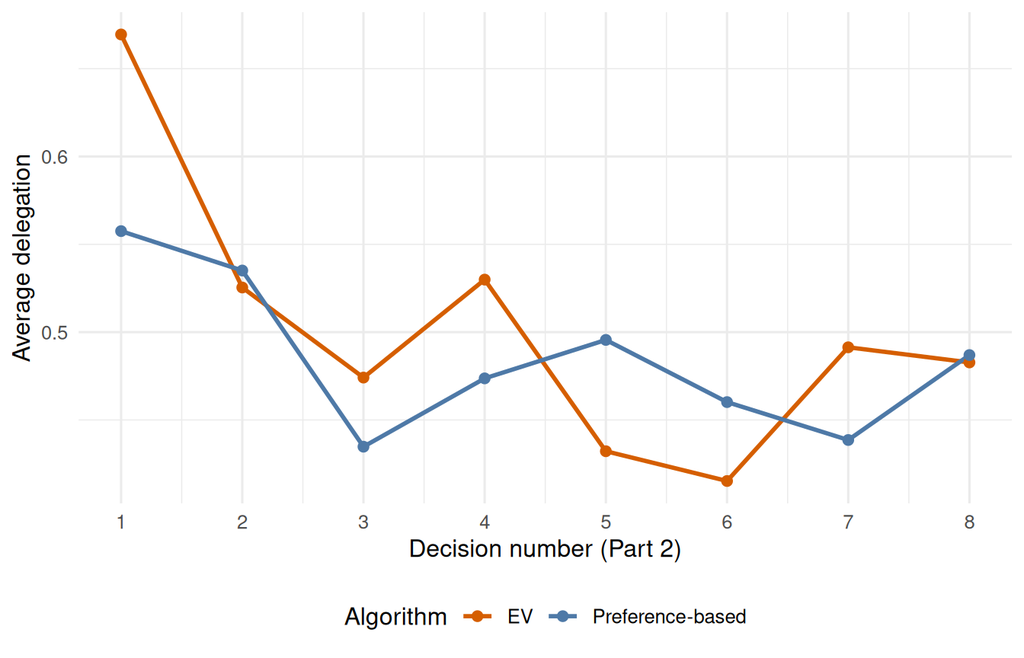

```r
fig1 <- choicesAv %>%
  mutate(Algorithm = factor(Algorithm, levels = c("EV", "Pref"),
                            labels = c("EV", "Preference-based"))) %>%
  ggplot(aes(x = WithinPartDecisionNumber, y = avDeleg,
             color = Algorithm, group = Algorithm)) +
  geom_line(linewidth = 1) +
  geom_point(size = 2) +
  scale_x_continuous(breaks = 1:8) +
  scale_color_manual(values = c("EV" = col_ev, "Preference-based" = col_pref)) +
  labs(x = "Decision number (Part 2)",
       y = "Average delegation",
       color = "Algorithm") +
  theme_minimal(base_size = 12) +
  theme(legend.position = "bottom")

fig1
```

```r
ggsave("Figure1_AverageDelegation.pdf", fig1, width = 7, height = 4.5)
```

# Primary test 1 — First-contact delegation (round 1)

Preregistered one-sided Boschloo exact test on round-1 delegation (paper: 66.9% vs. 55.8%, p = 0.0413).

```r
tab <- table(
  Delegated   = choices$Delegated[choices$Part == 2 & choices$WithinPartDecisionNumber == 1],
  EVAlgorithm = choices$EVAlgorithm[choices$Part == 2 & choices$WithinPartDecisionNumber == 1]
)

# Delegation share by condition (column 2 = EV)
prop.table(tab, margin = 2)
```

```
##          EVAlgorithm
## Delegated         0         1
##         0 0.4424779 0.3305085
##         1 0.5575221 0.6694915
```

```r
# One-sided Boschloo exact test (H1: EV > Pref)
exact.test(tab, method = "Boschloo", alternative = "greater", to.plot = FALSE)$p.value
```

```
## [1] 0.0412565
```

# Primary test 2 — Delegation across repeated decisions

## Participant-level Wilcoxon–Mann–Whitney test

Preregistered one-sided WMW test on participant-average delegation (paper: W = 6428, p = 0.2425).

```r
delegAv <- choices %>%
  filter(Part == 2) %>%
  group_by(Algorithm, ProlificID) %>%
  summarise(avDeleg = mean(Delegated, na.rm = TRUE), .groups = "drop") %>%
  mutate(Algorithm = factor(Algorithm, levels = c("Pref", "EV")))

wilcox.test(avDeleg ~ Algorithm, data = delegAv, alternative = "less")
```

```
##
##  Wilcoxon rank sum test with continuity correction
##
## data:  avDeleg by Algorithm
## W = 6428, p-value = 0.2425
## alternative hypothesis: true location shift is less than 0
```

## Figure 3 — ECDF of participant-level average delegation

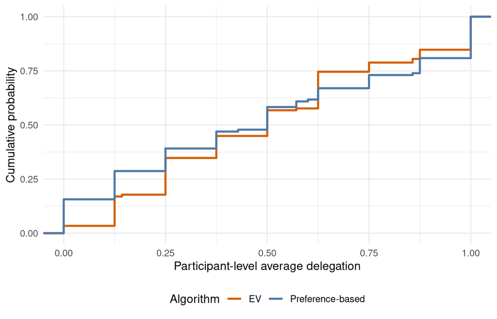

```r
fig3 <- delegAv %>%
  mutate(Algorithm = factor(Algorithm, levels = c("EV", "Pref"),
                            labels = c("EV", "Preference-based"))) %>%
  ggplot(aes(x = avDeleg, color = Algorithm)) +
  stat_ecdf(linewidth = 1) +
  scale_color_manual(values = c("EV" = col_ev, "Preference-based" = col_pref)) +
  labs(x = "Participant-level average delegation",
       y = "Cumulative probability",
       color = "Algorithm") +
  theme_minimal(base_size = 12) +
  theme(legend.position = "bottom")

fig3
```

```r
ggsave("Figure3_ECDF.pdf", fig3, width = 7, height = 4.5)
```

## Preregistered regression specification

LPM with decision-set fixed effects and participant-clustered SEs. We first construct the feedback-history regressor (running share of zero outcomes among prior delegated choices).

```r
choices <- choices %>%
  arrange(ProlificID, WithinPartDecisionNumber) %>%
  group_by(ProlificID) %>%
  mutate(
    delegated_round = (Delegated == 1),
    zero_payoff     = (RelevantPayoff == 0 & Delegated == 1),
    cum_delegated   = lag(cumsum(delegated_round), default = 0),
    cum_zero        = lag(cumsum(zero_payoff), default = 0),
    zero_rate       = ifelse(cum_delegated > 0, cum_zero / cum_delegated, NA)
  ) %>%
  ungroup()
```

```r
# Preregistered model: treatment x (period + feedback history)
delRegPreReg <- feols(
  Delegated ~ EVAlgorithm * (WithinPartDecisionNumber + zero_rate) | OptionsetID,
  cluster = ~ProlificID,
  data = subset(choices, Part == 2)
)
summary(delRegPreReg)
```

```
## OLS estimation, Dep. Var.: Delegated
## Observations: 1,324
## Fixed-effects: OptionsetID: 8
## Standard-errors: Clustered (ProlificID)
##                                       Estimate Std. Error   t value   Pr(>|t|)
## EVAlgorithm                          -0.048717   0.083122 -0.586090 5.5845e-01
## WithinPartDecisionNumber             -0.001795   0.008257 -0.217380 8.2813e-01
## zero_rate                            -0.385350   0.078139 -4.931567 1.6664e-06
## EVAlgorithm:WithinPartDecisionNumber  0.001877   0.011504  0.163119 8.7058e-01
## EVAlgorithm:zero_rate                -0.049677   0.097673 -0.508609 6.1157e-01
##
## EVAlgorithm
## WithinPartDecisionNumber
## zero_rate                            ***
## EVAlgorithm:WithinPartDecisionNumber
## EVAlgorithm:zero_rate
## ---
## Signif. codes:  0 '***' 0.001 '**' 0.01 '*' 0.05 '.' 0.1 ' ' 1
## RMSE: 0.467127     Adj. R2: 0.115951
##                  Within R2: 0.107265
```

## Supporting regressions

Plain treatment effect (all rounds; excluding round 1; round 1 only). The round-1-only LPM reproduces the Boschloo result ($\beta = 0.113$, one-sided $p = 0.041$).

```r
# All rounds, treatment only
delRegPlainTrmt <- feols(
  Delegated ~ EVAlgorithm | OptionsetID,
  cluster = ~ProlificID,
  data = subset(choices, Part == 2)
)

# Excluding round 1
delRegPlainTrmtNoP1 <- feols(
  Delegated ~ EVAlgorithm | OptionsetID,
  cluster = ~ProlificID,
  data = subset(choices, Part == 2 & WithinPartDecisionNumber > 1)
)

# Round 1 only (mirrors the Boschloo test)
delRegP1 <- feols(
  Delegated ~ EVAlgorithm | OptionsetID,
  cluster = ~ProlificID,
  data = subset(choices, Part == 2 & WithinPartDecisionNumber == 1)
)

screenreg(
  list(delRegPlainTrmt, delRegPlainTrmtNoP1, delRegP1),
  custom.model.names = c("All rounds", "Rounds 2-8", "Round 1 only"),
  caption = "Treatment effect on delegation (LPM, task FE, clustered SE)"
)
```

```
##
## ==============================================================
##                           All rounds  Rounds 2-8  Round 1 only
## --------------------------------------------------------------
## EVAlgorithm                  0.02        0.00       0.11
##                             (0.04)      (0.04)     (0.06)
## --------------------------------------------------------------
## Num. obs.                 1848        1617        231
## Num. groups: OptionsetID     8           8          8
## R^2 (full model)             0.01        0.01       0.05
## R^2 (proj model)             0.00        0.00       0.01
## Adj. R^2 (full model)        0.01        0.01       0.01
## Adj. R^2 (proj model)       -0.00       -0.00       0.01
## ==============================================================
## *** p < 0.001; ** p < 0.01; * p < 0.05
```

# Categorical non-delegation

We classify participants as never-, sometimes-, or always-delegators and compare never-delegation across conditions (paper: 15.7% Pref vs. 3.4% EV).

```r
choices <- choices %>%
  group_by(ProlificID) %>%
  mutate(sumDelegations = sum(Delegated)) %>%
  ungroup() %>%
  left_join(
    prolificData %>% select(Participant.id, TimeInSeconds = Time.taken),
    by = c("ProlificID" = "Participant.id")
  )

analysis_data <- choices %>%
  group_by(ProlificID) %>%
  summarise(
    EVAlgorithm                 = first(EVAlgorithm),
    sumDelegations              = first(sumDelegations),
    Female                      = first(Female),
    Age                         = first(Age),
    HHIncome                    = first(HHIncome),
    Education                   = first(Education),
    ProbOfBadComputerChoices    = first(ProbOfBadComputerChoices),
    ProbOfAbsurdComputerChoices = first(ProbOfAbsurdComputerChoices),
    ComputerRiskTaking          = first(ComputerRiskTaking),
    PBetChoices                 = first(PBet_count),
    TimeInSeconds               = first(TimeInSeconds),
    .groups = "drop"
  ) %>%
  mutate(
    DelegationGroup = ifelse(sumDelegations == 0, "Never", "AtLeastOnce"),
    NonDelegator    = 1 * (sumDelegations == 0),
    DelegatorType   = factor(
      if_else(sumDelegations == 0, "NeverDelegator",
              if_else(sumDelegations == 8, "AlwaysDelegator", "SometimesDelegator")),
      levels = c("NeverDelegator", "SometimesDelegator", "AlwaysDelegator")
    )
  ) %>%
  left_join(
    subjects %>% select(ProlificID, RiskTaking, FinMarketExperience,
                        FinanciallyResponsible, AIXperience),
    by = "ProlificID"
  )

# Distribution of delegator types by condition (column 2 = EV)
prop.table(table(analysis_data$DelegatorType, analysis_data$EVAlgorithm), margin = 2)
```

```
##
##                               0          1
##   NeverDelegator     0.15652174 0.03389831
##   SometimesDelegator 0.65217391 0.83050847
##   AlwaysDelegator    0.19130435 0.13559322
```

## Comparisons of never-delegators vs. delegators

The following tests reproduce the in-text comparisons (age, income, education, time, gender, risk-taking, reliability, AI experience, Part-1 satisfaction).

```r
# Age
t.test(Age ~ DelegationGroup, data = analysis_data)
```

```
##
##  Welch Two Sample t-test
##
## data:  Age by DelegationGroup
## t = 0.32876, df = 24.878, p-value = 0.7451
## alternative hypothesis: true difference in means between group AtLeastOnce and group Never is not equal to 0
## 95 percent confidence interval:
##  -5.689245  7.849952
## sample estimates:
## mean in group AtLeastOnce       mean in group Never
##                  42.85308                  41.77273
```

```r
# Time in experiment
t.test(TimeInSeconds ~ NonDelegator, data = analysis_data)
```

```
##
##  Welch Two Sample t-test
##
## data:  TimeInSeconds by NonDelegator
## t = -0.9713, df = 25.374, p-value = 0.3406
## alternative hypothesis: true difference in means between group 0 and group 1 is not equal to 0
## 95 percent confidence interval:
##  -385.8898  138.4297
## sample estimates:
## mean in group 0 mean in group 1
##        1113.043        1236.773
```

```r
# Household income (categorical)
chisq.test(table(analysis_data$DelegationGroup, analysis_data$HHIncome))
```

```
##
##  Pearson's Chi-squared test
##
## data:  table(analysis_data$DelegationGroup, analysis_data$HHIncome)
## X-squared = 13.171, df = 11, p-value = 0.2823
```

```r
# Education (categorical)
chisq.test(table(analysis_data$DelegationGroup, analysis_data$Education))
```

```
##
##  Pearson's Chi-squared test
##
## data:  table(analysis_data$DelegationGroup, analysis_data$Education)
## X-squared = 1.859, df = 5, p-value = 0.8683
```

```r
# Gender: never-delegation rate among males vs. females (Boschloo)
female_table <- table(
  DelegationGroup = analysis_data$DelegationGroup,
  Female          = analysis_data$Female
)
exact.test(female_table[, c(2, 4)], method = "Boschloo", to.plot = FALSE)$p.value
```

```
## [1] 0.1561955
```

```r
# Self-reported financial risk-taking, reliability, AI experience
t.test(RiskTaking  ~ NonDelegator, data = analysis_data)
```

```
##
##  Welch Two Sample t-test
##
## data:  RiskTaking by NonDelegator
## t = -0.22379, df = 24.99, p-value = 0.8247
## alternative hypothesis: true difference in means between group 0 and group 1 is not equal to 0
## 95 percent confidence interval:
##  -1.540832  1.238807
## sample estimates:
## mean in group 0 mean in group 1
##        4.530806        4.681818
```

```r
t.test(FinanciallyResponsible ~ NonDelegator, data = analysis_data)
```

```
##
##  Welch Two Sample t-test
##
## data:  FinanciallyResponsible by NonDelegator
## t = 1.229, df = 24.512, p-value = 0.2307
## alternative hypothesis: true difference in means between group 0 and group 1 is not equal to 0
## 95 percent confidence interval:
##  -0.6803629  2.6889799
## sample estimates:
## mean in group 0 mean in group 1
##        6.549763        5.545455
```

```r
t.test(AIXperience ~ NonDelegator, data = analysis_data)
```

```
##
##  Welch Two Sample t-test
##
## data:  AIXperience by NonDelegator
## t = 0.86582, df = 24.274, p-value = 0.3951
## alternative hypothesis: true difference in means between group 0 and group 1 is not equal to 0
## 95 percent confidence interval:
##  -0.9475606  2.3185214
## sample estimates:
## mean in group 0 mean in group 1
##        5.867299        5.181818
```

```r
# Within the preference-based condition: Part-1 satisfaction by delegation type
NeverDelegate <- choices %>%
  select(ProlificID, sumDelegations) %>%
  distinct() %>%
  mutate(sumDeleg0 = (sumDelegations == 0))

subjects2 <- subjects %>% left_join(NeverDelegate, by = "ProlificID")

subjects2 %>%
  filter(EVAlgorithm == 0) %>%
  group_by(sumDeleg0) %>%
  summarise(SatisfiedPart1 = mean(SatisfiedPart1, na.rm = TRUE),
            n = n(), .groups = "drop")
```

| sumDeleg0 | SatisfiedPart1 | n |
| --- | --- | --- |
| FALSE | 7.556701 | 97 |
| TRUE | 7.944444 | 18 |

# Responses to feedback (win-stay / lose-shift)

Win-stay/lose-shift model on rounds 2–8 (paper, Section “Responses to feedback”).

```r
choices <- choices %>%
  group_by(ProlificID) %>%
  arrange(WithinPartDecisionNumber, .by_group = TRUE) %>%
  mutate(
    lagDelegated          = lag(Delegated, 1),
    lagRelevantPayoff     = lag(RelevantPayoff, 1),
    lagSatisfactionRating = lag(SatisfactionRating, 1)
  ) %>%
  ungroup()

choices$stay <- 1 * (choices$Delegated == choices$lagDelegated)

# "Prior win": the outcome of the PREVIOUS round was strictly positive.
# (lagWin is defined from the lagged payoff, i.e. the genuine win-stay/lose-shift
# notion of reacting to the previously experienced outcome.)
choices$lagWin <- 1 * (choices$lagRelevantPayoff > 0)

# Pooled model: treatment x prior win
winStayReg <- feols(
  stay ~ EVAlgorithm * lagWin | OptionsetID + WithinPartDecisionNumber,
  cluster = ~ProlificID,
  data = subset(choices, Part == 2 & WithinPartDecisionNumber > 1)
)
summary(winStayReg)
```

```
## OLS estimation, Dep. Var.: stay
## Observations: 1,615
## Fixed-effects: OptionsetID: 8,  WithinPartDecisionNumber: 7
## Standard-errors: Clustered (ProlificID)
##                     Estimate Std. Error   t value   Pr(>|t|)
## EVAlgorithm        -0.104670   0.049740 -2.104353 3.6424e-02 *
## lagWin              0.169470   0.035178  4.817493 2.6258e-06 ***
## EVAlgorithm:lagWin  0.008762   0.048728  0.179822 8.5745e-01
## ---
## Signif. codes:  0 '***' 0.001 '**' 0.01 '*' 0.05 '.' 0.1 ' ' 1
## RMSE: 0.456921     Adj. R2: 0.052558
##                  Within R2: 0.043757
```

Separately by treatment, distinguishing whether the previous round was delegated (`lagDelegated == 1`, i.e. “the algorithm” produced the outcome) from a self-made choice. This separates lose-shift after one’s own loss from lose-shift after a delegated (algorithmic) loss.

```r
# EV condition
winStayReg_EV <- feols(
  stay ~ lagDelegated * I(1 - lagWin) | OptionsetID + WithinPartDecisionNumber,
  cluster = ~ProlificID,
  data = subset(choices, EVAlgorithm == 1 & Part == 2 & WithinPartDecisionNumber > 1)
)
summary(winStayReg_EV)
```

```
## OLS estimation, Dep. Var.: stay
## Observations: 819
## Fixed-effects: OptionsetID: 8,  WithinPartDecisionNumber: 7
## Standard-errors: Clustered (ProlificID)
##                             Estimate Std. Error   t value  Pr(>|t|)
## lagDelegated                0.044647   0.044771  0.997214 0.3207185
## I(1 - lagWin)              -0.075637   0.050734 -1.490836 0.1386957
## lagDelegated:I(1 - lagWin) -0.184727   0.069840 -2.645020 0.0092905 **
## ---
## Signif. codes:  0 '***' 0.001 '**' 0.01 '*' 0.05 '.' 0.1 ' ' 1
## RMSE: 0.473051     Adj. R2: 0.03568
##                  Within R2: 0.038964
```

```r
# Preference-based condition
winStayReg_Pref <- feols(
  stay ~ lagDelegated * I(1 - lagWin) | OptionsetID + WithinPartDecisionNumber,
  cluster = ~ProlificID,
  data = subset(choices, EVAlgorithm == 0 & Part == 2 & WithinPartDecisionNumber > 1)
)
summary(winStayReg_Pref)
```

```
## OLS estimation, Dep. Var.: stay
## Observations: 796
## Fixed-effects: OptionsetID: 8,  WithinPartDecisionNumber: 7
## Standard-errors: Clustered (ProlificID)
##                             Estimate Std. Error   t value Pr(>|t|)
## lagDelegated                0.024197   0.036355  0.665574 0.507028
## I(1 - lagWin)              -0.108747   0.048066 -2.262433 0.025565 *
## lagDelegated:I(1 - lagWin) -0.140381   0.063708 -2.203504 0.029570 *
## ---
## Signif. codes:  0 '***' 0.001 '**' 0.01 '*' 0.05 '.' 0.1 ' ' 1
## RMSE: 0.432604     Adj. R2: 0.058073
##                  Within R2: 0.042744
```

```r
# Average stay rates by condition, prior delegation, and prior win/loss
choices %>%
  filter(Part == 2, WithinPartDecisionNumber > 1) %>%
  group_by(EVAlgorithm, lagDelegated, lagWin) %>%
  summarise(avg_stay_rate = mean(stay, na.rm = TRUE),
            n = n(), .groups = "drop") %>%
  arrange(EVAlgorithm, lagDelegated, lagWin)
```

| EVAlgorithm | lagDelegated | lagWin | avg_stay_rate | n |
| --- | --- | --- | --- | --- |
| 0 | 0 | 0 | 0.6774194 | 155 |
| 0 | 0 | 1 | 0.7686275 | 255 |
| 0 | 1 | 0 | 0.5467626 | 139 |
| 0 | 1 | 1 | 0.7854251 | 247 |
| 0 | NA | NA | NaN | 2 |
| 1 | 0 | 0 | 0.5833333 | 144 |
| 1 | 0 | 1 | 0.6679389 | 262 |
| 1 | 1 | 0 | 0.4437870 | 169 |
| 1 | 1 | 1 | 0.6967213 | 244 |

# Exploratory mechanisms

## Coefficient model (interaction with performance expectations)

LPM of individual delegation decisions interacting treatment with participants’ algorithmic performance expectations, controlling for round, per-choice Part-1 confidence, revealed Part-1 risk preferences, and task fixed effects.

```r
delRegWConf <- feols(
  Delegated ~ EVAlgorithm * (WithinPartDecisionNumber + ConfidenceP1 +
    ProbOfAbsurdComputerChoices + ProbOfBadComputerChoices +
    EVChoices + truePChoices) | OptionsetID,
  cluster = ~ProlificID,
  data = subset(choices, Part == 2)
)
summary(delRegWConf)
```

```
## OLS estimation, Dep. Var.: Delegated
## Observations: 1,848
## Fixed-effects: OptionsetID: 8
## Standard-errors: Clustered (ProlificID)
##                                          Estimate Std. Error   t value
## EVAlgorithm                              0.856469   0.891957  0.960213
## WithinPartDecisionNumber                -0.009920   0.005711 -1.737089
## ConfidenceP1                            -0.025275   0.012620 -2.002676
## ProbOfAbsurdComputerChoices              0.009864   0.018425  0.535348
## ProbOfBadComputerChoices                -0.060048   0.016324 -3.678547
## EVChoices                                0.067083   0.058904  1.138847
## truePChoices                             0.058960   0.054107  1.089695
## EVAlgorithm:WithinPartDecisionNumber    -0.012262   0.008341 -1.470058
## EVAlgorithm:ConfidenceP1                 0.043682   0.015740  2.775229
## EVAlgorithm:ProbOfAbsurdComputerChoices -0.072908   0.023059 -3.161780
## EVAlgorithm:ProbOfBadComputerChoices     0.036186   0.020603  1.756318
## EVAlgorithm:EVChoices                   -0.089742   0.077330 -1.160496
## EVAlgorithm:truePChoices                -0.095940   0.071561 -1.340675
##                                          Pr(>|t|)
## EVAlgorithm                             0.3379475
## WithinPartDecisionNumber                0.0836987 .
## ConfidenceP1                            0.0463759 *
## ProbOfAbsurdComputerChoices             0.5929221
## ProbOfBadComputerChoices                0.0002916 ***
## EVChoices                               0.2559415
## truePChoices                            0.2769783
## EVAlgorithm:WithinPartDecisionNumber    0.1429009
## EVAlgorithm:ConfidenceP1                0.0059660 **
## EVAlgorithm:ProbOfAbsurdComputerChoices 0.0017772 **
## EVAlgorithm:ProbOfBadComputerChoices    0.0803535 .
## EVAlgorithm:EVChoices                   0.2470398
## EVAlgorithm:truePChoices                0.1813374
## ---
## Signif. codes:  0 '***' 0.001 '**' 0.01 '*' 0.05 '.' 0.1 ' ' 1
## RMSE: 0.474486     Adj. R2: 0.089466
##                  Within R2: 0.089764
```

## Figure A.1 — Condition-specific marginal effects

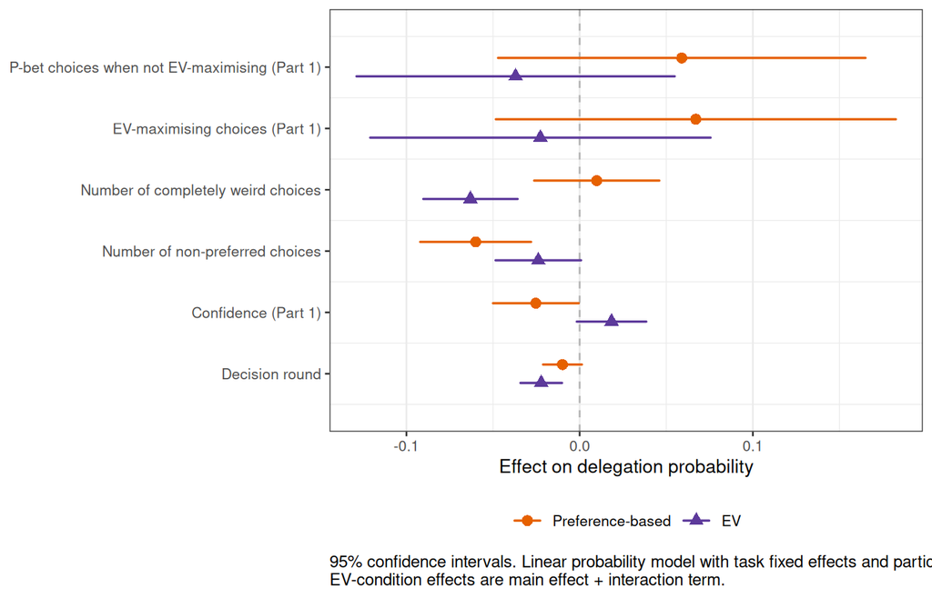

```r
coefs_wc <- coef(delRegWConf)
vcm_wc   <- vcov(delRegWConf)

# SE of the sum of two coefficients (main effect + interaction)
se_sum <- function(v1, v2) {
  sqrt(vcm_wc[v1, v1] + vcm_wc[v2, v2] + 2 * vcm_wc[v1, v2])
}

coef_spec <- data.frame(
  var_name = c("WithinPartDecisionNumber", "ConfidenceP1",
               "ProbOfBadComputerChoices", "ProbOfAbsurdComputerChoices",
               "EVChoices", "truePChoices"),
  var_label = c("Decision round", "Confidence (Part 1)",
                "Number of non-preferred choices",
                "Number of completely weird choices",
                "EV-maximising choices (Part 1)",
                "P-bet choices when not EV-maximising (Part 1)"),
  stringsAsFactors = FALSE
)

plot_data <- data.frame()
for (i in seq_len(nrow(coef_spec))) {
  var_name  <- coef_spec$var_name[i]
  var_label <- coef_spec$var_label[i]

  pb_est <- coefs_wc[var_name]
  pb_se  <- sqrt(vcm_wc[var_name, var_name])

  int_name <- paste0("EVAlgorithm:", var_name)
  if (int_name %in% names(coefs_wc)) {
    ev_est <- pb_est + coefs_wc[int_name]
    ev_se  <- se_sum(var_name, int_name)
  } else {
    ev_est <- pb_est
    ev_se  <- pb_se
  }

  plot_data <- rbind(plot_data, data.frame(
    Variable  = var_label,
    Condition = c("Preference-based", "EV"),
    Estimate  = c(pb_est, ev_est),
    SE        = c(pb_se, ev_se),
    stringsAsFactors = FALSE
  ))
}

plot_data <- plot_data %>%
  mutate(
    Variable  = factor(Variable, levels = coef_spec$var_label),
    Condition = factor(Condition, levels = c("Preference-based", "EV")),
    CI_lo = Estimate - 1.96 * SE,
    CI_hi = Estimate + 1.96 * SE,
    y_pos = as.numeric(Variable) +
      ifelse(Condition == "Preference-based", 0.15, -0.15)
  )

figA1 <- ggplot(plot_data) +
  geom_vline(xintercept = 0, linetype = "dashed", color = "gray70") +
  geom_linerange(aes(xmin = CI_lo, xmax = CI_hi, y = y_pos, color = Condition),
                 linewidth = 0.6, lineend = "round") +
  geom_point(aes(x = Estimate, y = y_pos, color = Condition, shape = Condition),
             size = 2.5) +
  scale_y_continuous(breaks = seq_len(nrow(coef_spec)),
                     labels = levels(plot_data$Variable),
                     expand = c(0.15, 0)) +
  scale_color_manual(values = c("Preference-based" = "#E66100", "EV" = "#5D3A9B")) +
  scale_shape_manual(values = c("Preference-based" = 16, "EV" = 17)) +
  labs(x = "Effect on delegation probability", y = NULL,
       color = NULL, shape = NULL,
       caption = paste0("95% confidence intervals. Linear probability model with ",
                        "task fixed effects and participant-clustered SEs.\n",
                        "EV-condition effects are main effect + interaction term.")) +
  theme_bw(base_size = 10) +
  theme(legend.position = "bottom",
        panel.grid.major.y = element_blank(),
        plot.caption = element_text(hjust = 0, size = 9))

figA1
```

```r
ggsave("CoefPlotBadAbsurd.pdf", figA1, width = 7, height = 4.5)
```

## Figure A.2 — Expected non-preferred and completely weird choices

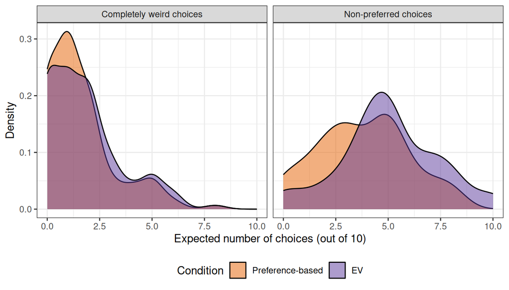

```r
figA2 <- subjects %>%
  pivot_longer(cols = c(ProbOfBadComputerChoices, ProbOfAbsurdComputerChoices),
               names_to = "variable", values_to = "value") %>%
  ggplot(aes(x = value, fill = factor(EVAlgorithm))) +
  geom_density(alpha = 0.5) +
  facet_wrap(~ variable, labeller = labeller(variable = c(
    ProbOfBadComputerChoices    = "Non-preferred choices",
    ProbOfAbsurdComputerChoices = "Completely weird choices"
  ))) +
  scale_fill_manual(values = c("0" = "#E66100", "1" = "#5D3A9B"),
                    labels = c("0" = "Preference-based", "1" = "EV"),
                    name = "Condition") +
  labs(x = "Expected number of choices (out of 10)", y = "Density") +
  theme_bw() +
  theme(legend.position = "bottom")

figA2
```

```r
ggsave("ExpectedBadAndAbsurdChoicesByTrmt.pdf", figA2, width = 7, height = 4)
```

## Treatment comparison of expected algorithmic errors

Formal comparison of expected non-preferred and completely weird choices across treatments. A LOWER expected number of non-preferred choices under the preference-based algorithm would indicate that participants believe the personalized algorithm is doing its job (matching their preferences).

```r
expect_tbl <- subjects %>%
  mutate(Condition = ifelse(EVAlgorithm == 1, "EV", "Preference-based")) %>%
  group_by(Condition) %>%
  summarise(
    n                  = n(),
    mean_nonpreferred  = mean(ProbOfBadComputerChoices, na.rm = TRUE),
    sd_nonpreferred    = sd(ProbOfBadComputerChoices, na.rm = TRUE),
    mean_weird         = mean(ProbOfAbsurdComputerChoices, na.rm = TRUE),
    sd_weird           = sd(ProbOfAbsurdComputerChoices, na.rm = TRUE),
    .groups = "drop"
  )
expect_tbl
```

| Condition | n | mean_nonpreferred | sd_nonpreferred | mean_weird | sd_weird |
| --- | --- | --- | --- | --- | --- |
| EV | 118 | 5.000000 | 2.316791 | 1.779661 | 1.740103 |
| Preference-based | 115 | 3.782609 | 2.159364 | 1.573913 | 1.617128 |

```r
# Expected NON-PREFERRED choices: EV vs. Preference-based
t.test(ProbOfBadComputerChoices ~ EVAlgorithm, data = subjects)
```

```
##
##  Welch Two Sample t-test
##
## data:  ProbOfBadComputerChoices by EVAlgorithm
## t = -4.1504, df = 230.54, p-value = 4.671e-05
## alternative hypothesis: true difference in means between group 0 and group 1 is not equal to 0
## 95 percent confidence interval:
##  -1.7953130 -0.6394696
## sample estimates:
## mean in group 0 mean in group 1
##        3.782609        5.000000
```

```r
wilcox.test(ProbOfBadComputerChoices ~ EVAlgorithm, data = subjects)
```

```
##
##  Wilcoxon rank sum test with continuity correction
##
## data:  ProbOfBadComputerChoices by EVAlgorithm
## W = 4805, p-value = 9.898e-05
## alternative hypothesis: true location shift is not equal to 0
```

```r
# Expected COMPLETELY WEIRD choices: EV vs. Preference-based
t.test(ProbOfAbsurdComputerChoices ~ EVAlgorithm, data = subjects)
```

```
##
##  Welch Two Sample t-test
##
## data:  ProbOfAbsurdComputerChoices by EVAlgorithm
## t = -0.93521, df = 230.48, p-value = 0.3507
## alternative hypothesis: true difference in means between group 0 and group 1 is not equal to 0
## 95 percent confidence interval:
##  -0.6392193  0.2277233
## sample estimates:
## mean in group 0 mean in group 1
##        1.573913        1.779661
```

```r
wilcox.test(ProbOfAbsurdComputerChoices ~ EVAlgorithm, data = subjects)
```

```
##
##  Wilcoxon rank sum test with continuity correction
##
## data:  ProbOfAbsurdComputerChoices by EVAlgorithm
## W = 6328, p-value = 0.361
## alternative hypothesis: true location shift is not equal to 0
```

# Post-task reasons

## Figure 4 — Reasons by treatment and delegation type

Reason-selection frequencies for the hypothetical additional-task choice, by treatment (EV vs. preference-based) and delegation type (delegators vs. never-delegators).

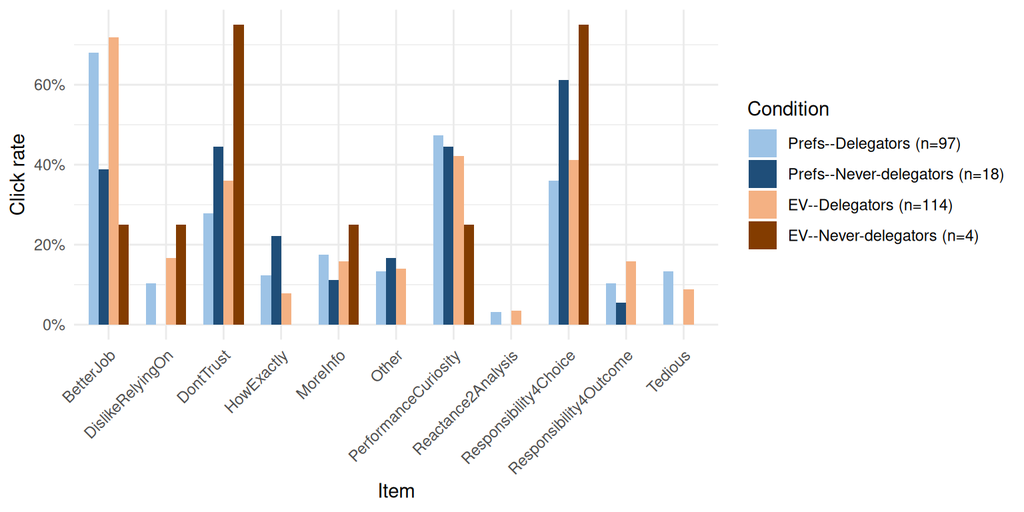

```r
subjects2 <- subjects %>% left_join(NeverDelegate, by = "ProlificID")

subjects_long <- subjects2 %>%
  pivot_longer(cols = DontTrust:Other, names_to = "item", values_to = "clicked")

# Group sizes for legend labels
n_labels <- subjects_long %>%
  group_by(sumDeleg0, EVAlgorithm) %>%
  summarise(n = n_distinct(ProlificID), .groups = "drop") %>%
  mutate(
    group = case_when(
      sumDeleg0 == TRUE  & EVAlgorithm == 0 ~ "Prefs--Never-delegators",
      sumDeleg0 == TRUE  & EVAlgorithm == 1 ~ "EV--Never-delegators",
      sumDeleg0 == FALSE & EVAlgorithm == 0 ~ "Prefs--Delegators",
      sumDeleg0 == FALSE & EVAlgorithm == 1 ~ "EV--Delegators"
    ),
    group_label = paste0(group, " (n=", n, ")")
  )

group_colors <- c(
  "Prefs--Delegators"       = "#9dc3e6",
  "Prefs--Never-delegators" = "#1f4e79",
  "EV--Delegators"          = "#f4b183",
  "EV--Never-delegators"    = "#833c00"
)
label_map <- setNames(n_labels$group_label, n_labels$group)

click_rates_both <- subjects_long %>%
  group_by(sumDeleg0, EVAlgorithm, item) %>%
  summarise(rate = mean(clicked, na.rm = TRUE), .groups = "drop") %>%
  mutate(
    group = case_when(
      sumDeleg0 == TRUE  & EVAlgorithm == 0 ~ "Prefs--Never-delegators",
      sumDeleg0 == TRUE  & EVAlgorithm == 1 ~ "EV--Never-delegators",
      sumDeleg0 == FALSE & EVAlgorithm == 0 ~ "Prefs--Delegators",
      sumDeleg0 == FALSE & EVAlgorithm == 1 ~ "EV--Delegators"
    ),
    group = factor(group, levels = names(group_colors))
  )

fig4 <- ggplot(click_rates_both, aes(x = item, y = rate, fill = group)) +
  geom_col(position = position_dodge(width = 0.7), width = 0.7) +
  scale_fill_manual(values = group_colors, labels = label_map,
                    breaks = names(group_colors), name = "Condition") +
  scale_y_continuous(labels = percent_format(accuracy = 1)) +
  labs(x = "Item", y = "Click rate") +
  theme_minimal() +
  theme(axis.text.x = element_text(angle = 45, hjust = 1),
        legend.position = "right")

fig4
```

```r
ggsave("ReasonsByTrmtAndNeverDelegator2.png", fig4, width = 8, height = 4, dpi = 300)
```

## Aggregate reason patterns

In-text figures for performance, distrust, and responsibility motives by delegation type (delegators vs. never-delegators).

```r
subjects_long %>%
  group_by(sumDeleg0, item) %>%
  summarise(rate = mean(clicked, na.rm = TRUE), .groups = "drop") %>%
  pivot_wider(names_from = sumDeleg0, values_from = rate) %>%
  rename(Delegators = `FALSE`, NeverDelegators = `TRUE`)
```

| item | Delegators | NeverDelegators |
| --- | --- | --- |
| BetterJob | 0.70142180 | 0.36363636 |
| DislikeRelyingOn | 0.13744076 | 0.04545455 |
| DontTrust | 0.32227488 | 0.50000000 |
| HowExactly | 0.09952607 | 0.18181818 |
| MoreInfo | 0.16587678 | 0.13636364 |
| Other | 0.13744076 | 0.13636364 |
| PerformanceCuriosity | 0.44549763 | 0.40909091 |
| Reactance2Analysis | 0.03317536 | 0.00000000 |
| Responsibility4Choice | 0.38862559 | 0.63636364 |
| Responsibility4Outcome | 0.13270142 | 0.04545455 |

[output cut: 1 more lines]

## LPM: never-delegation on reasons

```r
reason_vars <- c("DontTrust", "BetterJob", "HowExactly", "MoreInfo",
                 "Responsibility4Choice", "Responsibility4Outcome",
                 "DislikeRelyingOn", "Reactance2Analysis",
                 "PerformanceCuriosity", "Tedious", "Other")

# Bivariate LPMs (one per reason, HC2 SEs)
bivariate_tbl <- do.call(rbind, lapply(reason_vars, function(rv) {
  m  <- lm(as.formula(paste("as.numeric(sumDeleg0) ~", rv)), data = subjects2)
  ct <- coeftest(m, vcov = vcovHC(m, type = "HC2"))
  data.frame(reason = rv,
             coef = round(ct[2, 1], 3), se = round(ct[2, 2], 3),
             t = round(ct[2, 3], 3), p = round(ct[2, 4], 3))
}))
print(bivariate_tbl, row.names = FALSE)
```

```
##                  reason   coef    se      t     p
##               DontTrust  0.068 0.044  1.528 0.128
##               BetterJob -0.131 0.048 -2.739 0.007
##              HowExactly  0.073 0.077  0.950 0.343
##                MoreInfo -0.018 0.049 -0.376 0.707
##   Responsibility4Choice  0.087 0.041  2.111 0.036
##  Responsibility4Outcome -0.068 0.041 -1.688 0.093
##        DislikeRelyingOn -0.070 0.040 -1.769 0.078
##      Reactance2Analysis -0.097 0.020 -4.926 0.000
##    PerformanceCuriosity -0.013 0.038 -0.328 0.743
##                 Tedious -0.105 0.021 -4.945 0.000
##                   Other -0.001 0.056 -0.014 0.989
```

```r
# Joint LPM: full sample + preference-treatment only
f_joint  <- as.formula(paste("as.numeric(sumDeleg0) ~",
                             paste(reason_vars, collapse = " + ")))
lpm_all  <- lm(f_joint, data = subjects2)
lpm_pref <- lm(f_joint, data = subjects2[subjects2$EVAlgorithm == 0, ])

vcov_all  <- vcovHC(lpm_all,  type = "HC2")
vcov_pref <- vcovHC(lpm_pref, type = "HC2")

screenreg(
  list(lpm_all, lpm_pref),
  override.se = list(sqrt(diag(vcov_all)), sqrt(diag(vcov_pref))),
  override.pvalues = list(
    2 * pt(abs(coef(lpm_all)  / sqrt(diag(vcov_all))),
           df = lpm_all$df.residual,  lower.tail = FALSE),
    2 * pt(abs(coef(lpm_pref) / sqrt(diag(vcov_pref))),
           df = lpm_pref$df.residual, lower.tail = FALSE)
  ),
  custom.model.names = c("Full sample", "Pref. treatment"),
  caption = "LPM: never-delegation ~ reasons (HC2 SEs)"
)
```

```
##
## ====================================================
##                         Full sample  Pref. treatment
## ----------------------------------------------------
## (Intercept)               0.14 **      0.20 *
##                          (0.05)       (0.09)
## DontTrust                 0.08         0.15
##                          (0.04)       (0.09)
## BetterJob                -0.11 *      -0.14
##                          (0.05)       (0.08)
## HowExactly                0.04         0.05
##                          (0.08)       (0.10)
## MoreInfo                 -0.04        -0.15
##                          (0.06)       (0.11)
## Responsibility4Choice     0.06         0.11
##                          (0.04)       (0.07)
## Responsibility4Outcome   -0.04        -0.00
##                          (0.04)       (0.10)
## DislikeRelyingOn         -0.09 *      -0.25 **
##                          (0.04)       (0.08)
## Reactance2Analysis       -0.09        -0.12
##                          (0.04)       (0.12)
## PerformanceCuriosity      0.02         0.03
##                          (0.04)       (0.07)
## Tedious                  -0.07 **     -0.16 **
##                          (0.03)       (0.06)
## Other                    -0.02        -0.01
##                          (0.06)       (0.12)
## ----------------------------------------------------
## R^2                       0.10         0.16
## Adj. R^2                  0.05         0.06
## Num. obs.               233          115
## ====================================================
## *** p < 0.001; ** p < 0.01; * p < 0.05
```